Data Set - http://www.stat.ufl.edu/~winner/data/airq402.dat

Data Description - http://www.stat.ufl.edu/~winner/data/airq402.txt

# Assignment Expectations/Steps -

1. Import and store the data in a data frame. (2.5 points)
2. Remove the outliers from the data (5 points)
3. Treat “Average Fare” – 3rdColumn as your Dependent Variable and Rest of the columns as Independent Variable. (2.5 points)
4. Drop the independent variables which has less than 0.1 correlation with the dependent variable (5 points)
5. Create scatter Plot of Independent Variable vs Dependent Variable. (2.5 points)
6. Divide the data set into training and test data set and build a Multiple Linear Regression model. (5 points)
7. Print the coefficients & intercepts of the linear regression model (5 points)
8. Print the accuracy of the overall model (2.5 points)

# Dataset description

Dataset: airq402.dat

Source: U.S. Department of Transportation

Description: Airfsres and passengers for U.S. Domestic Routes for 4th Quarter of 2002.

Variables/Columns

1. City1 1-3
2. City2 5-7
3. Average Fare 11-17
4. Distance 20-23
5. Average weekly passengers 26-33
6. market leading airline 36-37
7. market share 40-45
8. Average fare 48-54
9. Low price airline 57-58
10. market share 61-66
11. price 69-75

```python
import pandas as pd
import numpy as np
import scipy as stats
```

## Step 1

- Import and store the data in a data frame. (2.5 points)

```python
dataset_url = 'http://www.stat.ufl.edu/~winner/data/airq402.dat'

df_airq = pd.read_table(dataset_url, header=None,
                      names=['all_in_one', 'City1', 'City2', 'Average Fare - 1', 'Distance', 'Average weekly passengers',
                             'market leading airline', 'market share - leading airline', 'Average fare - 2', 'Low price airline',
                             'market share - low price airline', 'price'], engine = 'python' )
```

```python
# Values are stored within defined character ranges of the line
# Since no delimeter is defined, therefore, all values will be saved in the first column, as concatenated value

# Below code will read the characters in the defined ranges (as per Dataset Description) and save to respective columns
df_airq['City1'] = (df_airq['all_in_one']).str[0:3]
df_airq['City2'] = (df_airq['all_in_one']).str[4:7]
df_airq['Average Fare - 1'] = (df_airq['all_in_one']).str[10:17]
df_airq['Distance'] = (df_airq['all_in_one']).str[19:23]
df_airq['Average weekly passengers'] = (df_airq['all_in_one']).str[25:33]
df_airq['market leading airline'] = (df_airq['all_in_one']).str[35:37]
df_airq['market share - leading airline'] = (df_airq['all_in_one']).str[39:45]
df_airq['Average fare - 2'] = (df_airq['all_in_one']).str[47:54]
df_airq['Low price airline'] = (df_airq['all_in_one']).str[56:58]
df_airq['market share - low price airline'] = (df_airq['all_in_one']).str[60:66]
df_airq['price'] = (df_airq['all_in_one']).str[68:75]

# Drop the very first column, which contains concatenation of all values
df_airq.drop('all_in_one', axis=1, inplace=True)

df_airq.head()
```

|  | City1 | City2 | Average Fare - 1 | Distance | Average weekly passengers | market leading airline | market share - leading airline | Average fare - 2 | Low price airline | market share - low price airline | price |
| --- | --- | --- | --- | --- | --- | --- | --- | --- | --- | --- | --- |
| 0 | CAK | ATL | 114.47 | 528 | 424.56 | FL | 70.19 | 111.03 | FL | 70.19 | 111.03 |
| 1 | CAK | MCO | 122.47 | 860 | 276.84 | FL | 75.10 | 123.09 | DL | 17.23 | 118.94 |
| 2 | ALB | ATL | 214.42 | 852 | 215.76 | DL | 78.89 | 223.98 | CO | 2.77 | 167.12 |
| 3 | ALB | BWI | 69.40 | 288 | 606.84 | WN | 96.97 | 68.86 | WN | 96.97 | 68.86 |
| 4 | ALB | ORD | 158.13 | 723 | 313.04 | UA | 39.79 | 161.36 | WN | 15.34 | 145.42 |

## Step 2

- Remove the outliers from the data (5 points)

```python
# Change data types to numeric before checking outliers
df_airq['Average Fare - 1'] = pd.to_numeric(df_airq['Average Fare - 1'])
df_airq['Distance'] = pd.to_numeric(df_airq['Distance'])
df_airq['Average weekly passengers'] = pd.to_numeric(df_airq['Average weekly passengers'])
df_airq['market share - leading airline'] = pd.to_numeric(df_airq['market share - leading airline'])
df_airq['Average fare - 2'] = pd.to_numeric(df_airq['Average fare - 2'])
df_airq['market share - low price airline'] = pd.to_numeric(df_airq['market share - low price airline'])
df_airq['price'] = pd.to_numeric(df_airq['price'])

df_airq.describe().T
```

|  | count | mean | std | min | 25% | 50% | 75% | max |
| --- | --- | --- | --- | --- | --- | --- | --- | --- |
| Average Fare - 1 | 1000.0 | 163.37542 | 55.365470 | 50.52 | 125.9750 | 161.345 | 197.3925 | 401.23 |
| Distance | 1000.0 | 1056.97300 | 643.203251 | 108.00 | 553.5000 | 919.000 | 1452.5000 | 2724.00 |
| Average weekly passengers | 1000.0 | 672.27914 | 766.519254 | 181.41 | 257.1975 | 404.780 | 769.9125 | 8950.76 |
| market share - leading airline | 1000.0 | 60.12859 | 19.367779 | 17.68 | 46.5100 | 59.240 | 73.5100 | 100.00 |
| Average fare - 2 | 1000.0 | 166.64756 | 62.660140 | 50.52 | 124.0850 | 161.400 | 202.9775 | 490.03 |
| market share - low price airline | 1000.0 | 34.55148 | 27.096999 | 1.06 | 13.1950 | 26.140 | 52.9725 | 100.00 |
| price | 1000.0 | 143.19309 | 47.229184 | 49.61 | 113.7675 | 137.825 | 168.5300 | 387.94 |

```python
# Check outliers from following fields:
    # Distance
    # Average weekly passengers
    # Average fare - 2
    # price

# Method to identify and replace outliers with mean
def removeOutliers(x, column_name):
    a = np.array(x)
    q3 = np.percentile(a, 75)
    q1 = np.percentile(a, 25)
    iqr = q3 - q1
    quartileSet = [q1 - 1.5*iqr, q3 + 1.5*iqr]
    mean = x.mean()
    resultList = []
    for i in range(len(a)):
        if a[i] <= quartileSet[0] or a[i] >= quartileSet[1]:
            resultList.append(a[i])
            a[i] = mean
    print("---***---")
    print("COLUMN NAME: ", column_name)
    print("Quartile Set: ", quartileSet)
    print("Mean: ", mean)
    print("Number of outliers: ", len(resultList))
    print("Outliers: ", resultList)
    # x = pd.Series(a)
    return pd.Series(a)

df_airq['Distance'] = removeOutliers(df_airq['Distance'], 'Distance')
df_airq['Average weekly passengers'] = removeOutliers(df_airq['Average weekly passengers'], 'Average weekly passengers')
df_airq['Average fare - 2'] = removeOutliers(df_airq['Average fare - 2'], 'Average fare - 2')
df_airq['price'] = removeOutliers(df_airq['price'], 'price')
```

[output not shown]

## Step 3

- Treat “Average Fare” – 3rdColumn as your Dependent Variable and Rest of the columns as Independent Variable. (2.5 points)

OK! Treating the 3rd Column (Average Fare - 1) as the dependent variable (target) in further steps.

## Step 4

- Drop the independent variables which has less than 0.1 correlation with the dependent variable (5 points)

```python
df_airq.corr()
```

|  | Average Fare - 1 | Distance | Average weekly passengers | market share - leading airline | Average fare - 2 | market share - low price airline | price |
| --- | --- | --- | --- | --- | --- | --- | --- |
| Average Fare - 1 | 1.000000 | 0.587169 | -0.149291 | -0.234142 | 0.907092 | -0.458660 | 0.777960 |
| Distance | 0.587169 | 1.000000 | -0.107459 | -0.531406 | 0.501522 | -0.367831 | 0.549958 |
| Average weekly passengers | -0.149291 | -0.107459 | 1.000000 | 0.010812 | -0.167651 | 0.077037 | -0.211388 |
| market share - leading airline | -0.234142 | -0.531406 | 0.010812 | 1.000000 | -0.204738 | 0.306832 | -0.313359 |
| Average fare - 2 | 0.907092 | 0.501522 | -0.167651 | -0.204738 | 1.000000 | -0.491544 | 0.753968 |
| market share - low price airline | -0.458660 | -0.367831 | 0.077037 | 0.306832 | -0.491544 | 1.000000 | -0.281315 |
| price | 0.777960 | 0.549958 | -0.211388 | -0.313359 | 0.753968 | -0.281315 | 1.000000 |

```python
df_airq.corr().iloc[0]
```

```
Average Fare - 1                    1.000000
Distance                            0.587169
Average weekly passengers          -0.149291
market share - leading airline     -0.234142
Average fare - 2                    0.907092
market share - low price airline   -0.458660
price                               0.777960
Name: Average Fare - 1, dtype: float64
```

As no independent variable has correlation between -0.1 and + 0.1 with the dependent variable, therefore none of the column will be dropped.

## Step 5

- Create scatter Plot of Independent Variable vs Dependent Variable. (2.5 points)

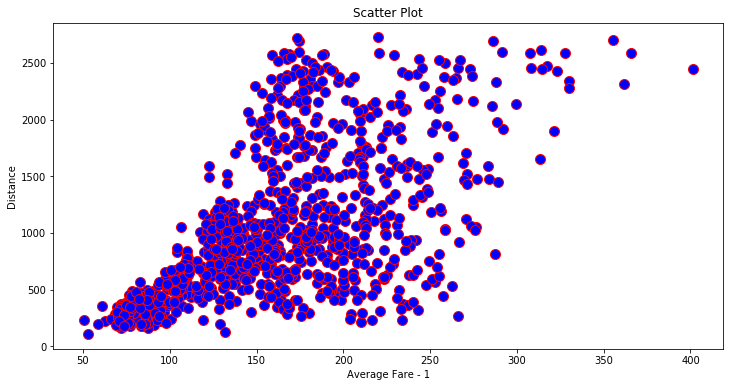

```python
# import seaborn as sns
# df_attr = df_airq.iloc[:,:]
# sns.pairplot(df_attr)

import matplotlib.pyplot as plt
%matplotlib inline

# Draw scatter plot of target column ('Average Fare - 1') against the independent variables

# Distance
plt.figure(figsize=(12, 6))
plt.plot(df_airq['Average Fare - 1'], df_airq['Distance'], color='red', linestyle='', marker='o',
         markerfacecolor='blue', markersize=10)
plt.title('Scatter Plot')
plt.xlabel('Average Fare - 1')
plt.ylabel('Distance')
```

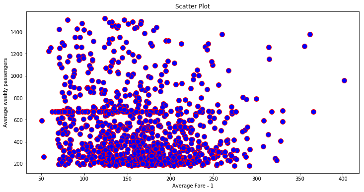

```python
# Average weekly passengers
plt.figure(figsize=(12, 6))
plt.plot(df_airq['Average Fare - 1'], df_airq['Average weekly passengers'], color='red', linestyle='', marker='o',
         markerfacecolor='blue', markersize=10)
plt.title('Scatter Plot')
plt.xlabel('Average Fare - 1')
plt.ylabel('Average weekly passengers')
```

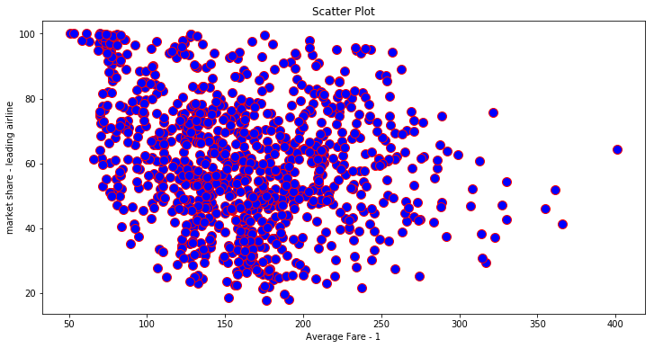

```python
# market share - leading airline
plt.figure(figsize=(12, 6))
plt.plot(df_airq['Average Fare - 1'], df_airq['market share - leading airline'], color='red', linestyle='', marker='o',
         markerfacecolor='blue', markersize=10)
plt.title('Scatter Plot')
plt.xlabel('Average Fare - 1')
plt.ylabel('market share - leading airline')
```

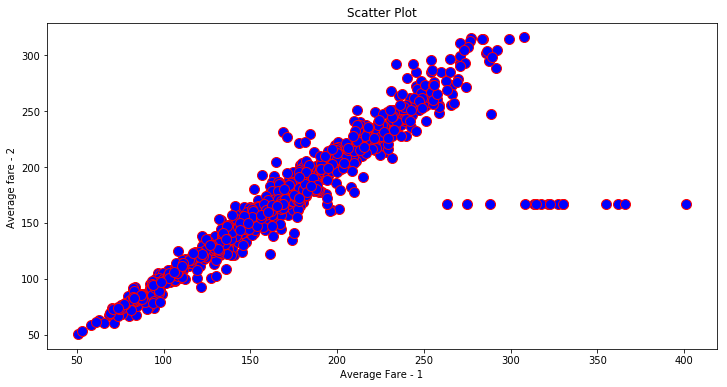

```python
# Average fare - 2
plt.figure(figsize=(12, 6))
plt.plot(df_airq['Average Fare - 1'], df_airq['Average fare - 2'], color='red', linestyle='', marker='o',
         markerfacecolor='blue', markersize=10)
plt.title('Scatter Plot')
plt.xlabel('Average Fare - 1')
plt.ylabel('Average fare - 2 ')
```

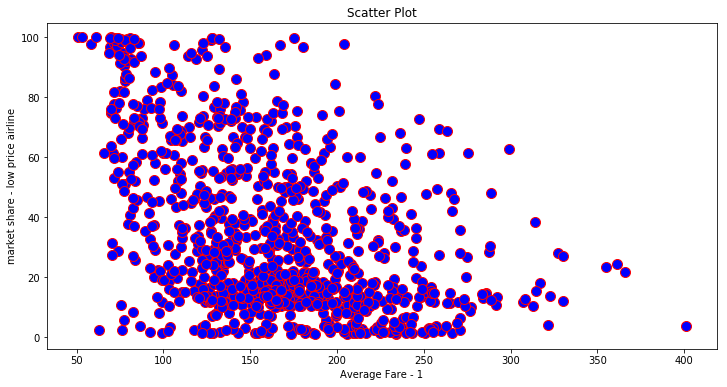

```python
# market share - low price airline
plt.figure(figsize=(12, 6))
plt.plot(df_airq['Average Fare - 1'], df_airq['market share - low price airline'], color='red', linestyle='', marker='o',
         markerfacecolor='blue', markersize=10)
plt.title('Scatter Plot')
plt.xlabel('Average Fare - 1')
plt.ylabel('market share - low price airline')
```

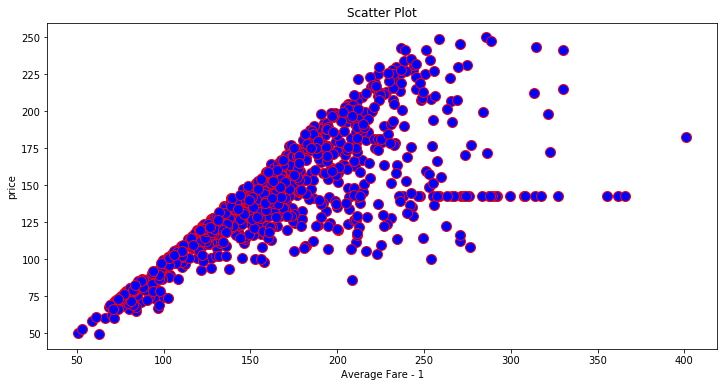

```python
# price
plt.figure(figsize=(12, 6))
plt.plot(df_airq['Average Fare - 1'], df_airq['price'], color='red', linestyle='', marker='o',
         markerfacecolor='blue', markersize=10)
plt.title('Scatter Plot')
plt.xlabel('Average Fare - 1')
plt.ylabel('price')
```

## Step 6

- Divide the data set into training and test data set and build a Multiple Linear Regression model. (5 points)

```python
# Create dummies
df_airq['City1'].describe()
df_airq['City2'].describe()
df_airq['market leading airline'].describe()
df_airq['Low price airline'].describe()

# Create dummies
#marketLeading_dum = pd.get_dummies(df_airq['market leading airline'], dummy_na = False, prefix="lead")
#lowPriceAir_dum = pd.get_dummies(df_airq['Low price airline'], dummy_na = False, prefix="lowPri")
#df_airq_1 = pd.concat([df_airq, marketLeading_dum, lowPriceAir_dum], axis=1)
#df_airq_1.head()

# WHY NOT APPLYING DUMMIES: Applying dummies to below two columns was redusing the adjusted R-squared value.
# Therefore, not using dummies

df_airq_1 = df_airq   # If dummy is not applied
```

```python
from sklearn.model_selection import train_test_split

X = df_airq_1.drop(['City1', 'City2', 'Average Fare - 1', 'market leading airline', 'Low price airline'], axis=1)
y = df_airq_1['Average Fare - 1']

X_train, X_test, y_train, y_test = train_test_split(X, y, test_size=0.20, random_state=7)

X.head()
```

|  | Distance | Average weekly passengers | market share - leading airline | Average fare - 2 | market share - low price airline | price |
| --- | --- | --- | --- | --- | --- | --- |
| 0 | 528 | 424.56 | 70.19 | 111.03 | 70.19 | 111.03 |
| 1 | 860 | 276.84 | 75.10 | 123.09 | 17.23 | 118.94 |
| 2 | 852 | 215.76 | 78.89 | 223.98 | 2.77 | 167.12 |
| 3 | 288 | 606.84 | 96.97 | 68.86 | 96.97 | 68.86 |
| 4 | 723 | 313.04 | 39.79 | 161.36 | 15.34 | 145.42 |

```python
from sklearn import linear_model

regr = linear_model.LinearRegression()
regr.fit(X_train, y_train)
```

```
LinearRegression(copy_X=True, fit_intercept=True, n_jobs=None,
         normalize=False)
```

## Step 7

- Print the coefficients & intercepts of the linear regression model (5 points)

```python
print('intercept:', regr.intercept_)
print('coefficient:', regr.coef_)
```

```
intercept: -7.220205219310117
coefficient: [ 0.01625579  0.00364134  0.1885511   0.6823788  -0.05672231  0.22399193]
```

## Step 8

- Print the accuracy of the overall model (2.5 points)

```python
from sklearn.metrics import r2_score

y_predicted = regr.predict(X_test)

r_sq = r2_score(y_test, y_predicted)
ad_r_sq = 1 - (1 - r_sq) * (len(y_train) - 1) / (len(y_train) - X.shape[1] - 1)

print("R squared: ", r_sq)
print("Accuracy (adujsted r square score): ", ad_r_sq)
```

```
R squared:  0.8825180312124913
Accuracy (adujsted r square score):  0.8816291386365455
```